# housing price index eda for EJW

Hongjie Wang

April 24, 2021

We show an example of getting data from web, perform some EDA. As a demontration for EJW.

First, we load some packages

```r
rm(list = ls())
library(rvest)
library(tidyverse)
```

```r
library(ggplot2)
library(GGally)
```

We first obtain data from a table embedded in HTML page We use the functions in rvest package for this step.

```r
data_url<-"https://wiki.socr.umich.edu/index.php/SOCR_Data_Dinov_091609_SnP_HomePriceIndex"
wiki_url<- read_html(data_url)

mydata<-wiki_url%>%
  html_node("table")%>%
  html_table()
```

Some high level summary of the data to make sure all the types are correct.

```r
str(mydata)
```

```
## tibble [222 x 23] (S3: tbl_df/tbl/data.frame)
##  $ Index          : int [1:222] 1 2 3 4 5 6 7 8 9 10 ...
##  $ Year           : int [1:222] 1991 1991 1991 1991 1991 1991 1991 1991 1991 1991 ...
##  $ Month          : chr [1:222] "January" "February" "March" "April" ...
##  $ AZ-Phoenix     : num [1:222] 65.3 65.3 64.6 64.3 64.4 ...
##  $ CA-LosAngeles  : num [1:222] 95.3 94.1 92.8 92.8 93.4 ...
##  $ CA-SanDiego    : num [1:222] 83.1 81.9 80.9 80.7 81.4 ...
##  $ CA-SanFrancisco: num [1:222] 71.2 70.3 69.6 69.5 70.1 ...
##  $ CO-Denver      : num [1:222] 48.7 48.7 48.9 49.2 49.5 ...
##  $ DC-Washington  : num [1:222] 89.4 88.8 87.6 87.6 88.6 ...
##  $ FL-Miami       : num [1:222] 79.1 78.5 78.4 78.5 78 ...
##  $ FL-Tampa       : num [1:222] 81.8 81.8 81.4 81.5 81.3 ...
##  $ GA-Atlanta     : num [1:222] 69.6 69.2 69 69.4 69.7 ...
##  $ IL-Chicago     : num [1:222] 70 70.5 70.6 71.1 71.4 ...
##  $ MA-Boston      : num [1:222] 65 64.2 63.6 63.4 63.8 ...
##  $ MI-Detroit     : num [1:222] 58.2 57.8 57.6 57.9 58.4 ...
##  $ MN-Minneapolis : num [1:222] 64.2 64.2 64.2 64.3 64.8 ...
##  $ NC-Charlotte   : num [1:222] 73.3 73.3 72.8 72.9 73.3 ...
##  $ NV-LasVegas    : num [1:222] 81 81.6 81.7 81.7 82 ...
##  $ NY-NewYork     : num [1:222] 74.6 73.7 72.9 72.3 72.6 ...
##  $ OH-Cleveland   : num [1:222] 68.2 68 68.2 69.1 69.9 ...
##  $ OR-Portland    : num [1:222] 56.5 56.9 58 58.4 58.9 ...
##  $ WA-Seattle     : num [1:222] 65.5 64.6 64.5 65.1 66 ...
##  $ Composite-10   : num [1:222] 78.5 77.8 77 76.9 77.3 ...
```

```r
head(mydata,10)
```

```
## # A tibble: 10 x 23
##    Index  Year Month `AZ-Phoenix` `CA-LosAngeles` `CA-SanDiego` `CA-SanFrancisc~
##    <int> <int> <chr>        <dbl>           <dbl>         <dbl>            <dbl>
##  1     1  1991 Janu~         65.3            95.3          83.1             71.2
##  2     2  1991 Febr~         65.3            94.1          81.9             70.3
##  3     3  1991 March         64.6            92.8          80.9             69.6
##  4     4  1991 April         64.4            92.8          80.7             69.5
##  5     5  1991 May           64.4            93.4          81.4             70.1
##  6     6  1991 June          64.9            94.2          82.2             70.8
##  7     7  1991 July          65.5            94.8          82.6             71.4
##  8     8  1991 Augu~         65.9            95.2          82.5             71.5
##  9     9  1991 Sept~         66.0            94.9          82.2             71.6
## 10    10  1991 Octo~         65.8            94.5          82.0             71.2
## # ... with 16 more variables: CO-Denver <dbl>, DC-Washington <dbl>,
## #   FL-Miami <dbl>, FL-Tampa <dbl>, GA-Atlanta <dbl>, IL-Chicago <dbl>,
## #   MA-Boston <dbl>, MI-Detroit <dbl>, MN-Minneapolis <dbl>,
## #   NC-Charlotte <dbl>, NV-LasVegas <dbl>, NY-NewYork <dbl>,
## #   OH-Cleveland <dbl>, OR-Portland <dbl>, WA-Seattle <dbl>, Composite-10 <dbl>
```

```r
tail(mydata,5)
```

```
## # A tibble: 5 x 23
##   Index  Year Month  `AZ-Phoenix` `CA-LosAngeles` `CA-SanDiego` `CA-SanFrancisc~
##   <int> <int> <chr>         <dbl>           <dbl>         <dbl>            <dbl>
## 1   218  2009 Febru~         112.            163.          147.             120.
## 2   219  2009 March          107.            161.          145.             118.
## 3   220  2009 April          104.            159.          144.             118.
## 4   221  2009 May            104.            159.          145.             120.
## 5   222  2009 June           105.            161.          147.             125.
## # ... with 16 more variables: CO-Denver <dbl>, DC-Washington <dbl>,
## #   FL-Miami <dbl>, FL-Tampa <dbl>, GA-Atlanta <dbl>, IL-Chicago <dbl>,
## #   MA-Boston <dbl>, MI-Detroit <dbl>, MN-Minneapolis <dbl>,
## #   NC-Charlotte <dbl>, NV-LasVegas <dbl>, NY-NewYork <dbl>,
## #   OH-Cleveland <dbl>, OR-Portland <dbl>, WA-Seattle <dbl>, Composite-10 <dbl>
```

```r
summary(mydata)
```

```
##      Index             Year         Month             AZ-Phoenix
##  Min.   :  1.00   Min.   :1991   Length:222         Min.   : 64.35
##  1st Qu.: 56.25   1st Qu.:1995   Class :character   1st Qu.: 77.75
##  Median :111.50   Median :2000   Mode  :character   Median :101.78
##  Mean   :111.50   Mean   :2000                      Mean   :114.39
##  3rd Qu.:166.75   3rd Qu.:2004                      3rd Qu.:129.70
##  Max.   :222.00   Max.   :2009                      Max.   :227.42
##  CA-LosAngeles     CA-SanDiego     CA-SanFrancisco    CO-Denver
##  Min.   : 73.07   Min.   : 71.22   Min.   : 65.79   Min.   : 48.67
##  1st Qu.: 81.27   1st Qu.: 76.36   1st Qu.: 69.47   1st Qu.: 70.69
##  Median :102.92   Median :104.34   Median :108.77   Median :102.53
##  Mean   :135.83   Mean   :131.41   Mean   :119.18   Mean   : 99.17
##  3rd Qu.:180.32   3rd Qu.:177.37   3rd Qu.:154.31   3rd Qu.:127.45
##  Max.   :273.94   Max.   :250.34   Max.   :218.37   Max.   :140.28
##  DC-Washington       FL-Miami         FL-Tampa        GA-Atlanta
##  Min.   : 87.56   Min.   : 77.61   Min.   : 80.27   Min.   : 69.05
##  1st Qu.: 89.19   1st Qu.: 87.04   1st Qu.: 87.05   1st Qu.: 79.65
##  Median :102.52   Median :101.28   Median :101.39   Median :101.84
##  Mean   :135.63   Mean   :135.34   Mean   :125.70   Mean   :100.51
##  3rd Qu.:176.35   3rd Qu.:169.91   3rd Qu.:154.35   3rd Qu.:118.96
##  Max.   :251.07   Max.   :280.87   Max.   :238.09   Max.   :136.47
##    IL-Chicago       MA-Boston        MI-Detroit     MN-Minneapolis
##  Min.   : 70.04   Min.   : 62.94   Min.   : 57.63   Min.   : 64.19
##  1st Qu.: 83.41   1st Qu.: 70.10   1st Qu.: 70.50   1st Qu.: 76.02
##  Median :102.16   Median :102.29   Median : 92.79   Median :101.30
##  Mean   :111.44   Mean   :114.18   Mean   : 92.76   Mean   :110.41
##  3rd Qu.:138.97   3rd Qu.:158.67   3rd Qu.:114.62   3rd Qu.:144.09
##  Max.   :168.60   Max.   :182.45   Max.   :127.05   Max.   :171.12
##   NC-Charlotte     NV-LasVegas       NY-NewYork      OH-Cleveland
##  Min.   : 72.75   Min.   : 80.96   Min.   : 72.29   Min.   : 67.96
##  1st Qu.: 83.96   1st Qu.: 88.68   1st Qu.: 78.88   1st Qu.: 84.15
##  Median :101.59   Median :101.05   Median :101.84   Median : 99.68
##  Mean   :100.36   Mean   :125.72   Mean   :125.10   Mean   : 98.21
##  3rd Qu.:113.80   3rd Qu.:146.63   3rd Qu.:175.19   3rd Qu.:112.00
##  Max.   :135.88   Max.   :234.78   Max.   :215.83   Max.   :123.49
##   OR-Portland       WA-Seattle      Composite-10
##  Min.   : 56.53   Min.   : 64.47   Min.   : 75.63
##  1st Qu.: 81.28   1st Qu.: 72.49   1st Qu.: 77.94
##  Median :101.45   Median :102.85   Median :103.12
##  Mean   :110.39   Mean   :109.91   Mean   :125.40
##  3rd Qu.:134.33   3rd Qu.:137.06   3rd Qu.:167.42
##  Max.   :186.51   Max.   :192.30   Max.   :226.29
```

We replace the year and month with a date field.

```r
temp=seq(as.Date('1991-01-01'),as.Date('2009-06-01'),by='month')
mydata<-mydata%>%
  mutate(date_field=temp)%>%
  select(-Year,-Month)
head(mydata)
```

```
## # A tibble: 6 x 22
##   Index `AZ-Phoenix` `CA-LosAngeles` `CA-SanDiego` `CA-SanFrancisco` `CO-Denver`
##   <int>        <dbl>           <dbl>         <dbl>             <dbl>       <dbl>
## 1     1         65.3            95.3          83.1              71.2        48.7
## 2     2         65.3            94.1          81.9              70.3        48.7
## 3     3         64.6            92.8          80.9              69.6        48.8
## 4     4         64.4            92.8          80.7              69.5        49.2
## 5     5         64.4            93.4          81.4              70.1        49.5
## 6     6         64.9            94.2          82.2              70.8        50.1
## # ... with 16 more variables: DC-Washington <dbl>, FL-Miami <dbl>,
## #   FL-Tampa <dbl>, GA-Atlanta <dbl>, IL-Chicago <dbl>, MA-Boston <dbl>,
## #   MI-Detroit <dbl>, MN-Minneapolis <dbl>, NC-Charlotte <dbl>,
## #   NV-LasVegas <dbl>, NY-NewYork <dbl>, OH-Cleveland <dbl>, OR-Portland <dbl>,
## #   WA-Seattle <dbl>, Composite-10 <dbl>, date_field <date>
```

we change the data from wide format to long format so that we can plot price curves by location

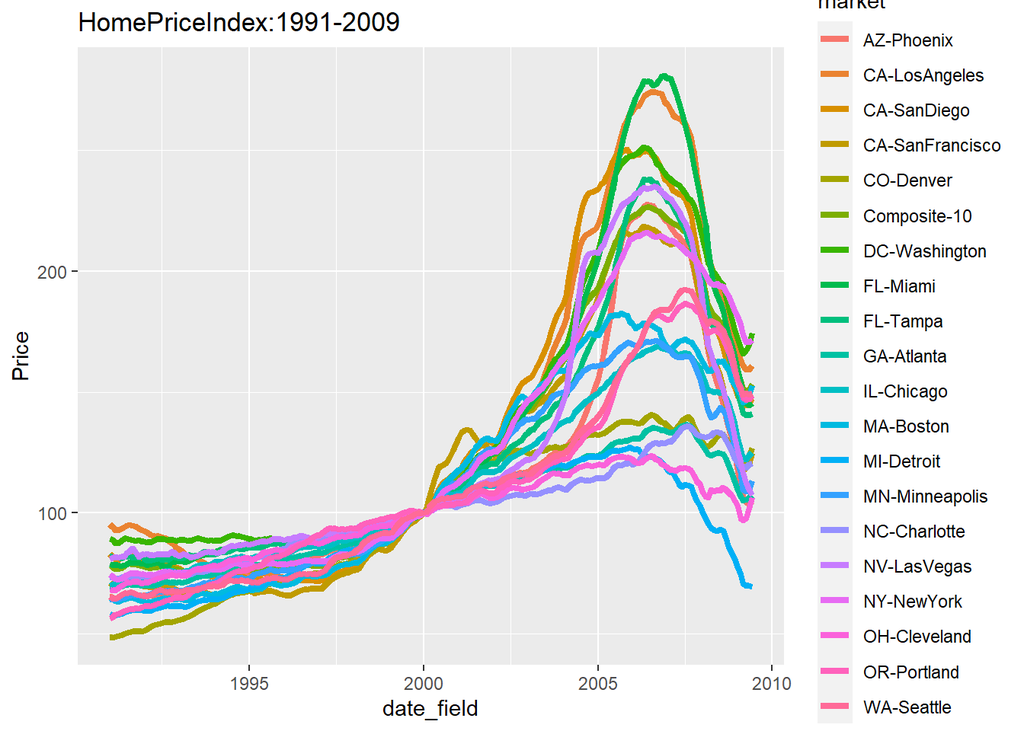

```r
mydata%>%
  select(-Index)%>%
  gather(-date_field,key="market",value="Price")%>%
  ggplot(aes(x=date_field, y=Price, color=market)) +
geom_line(size=1.5) + ggtitle("HomePriceIndex:1991-2009")
```

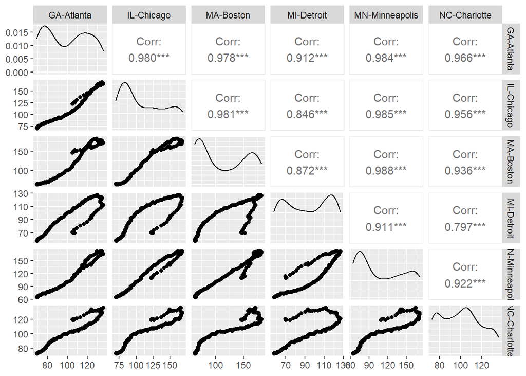

```r
subset<-mydata[,10:15]
ggpairs(subset)
```

We can examine one particular market (Boston) more closely

```r
boston<-mydata$`MA-Boston`

summary(boston)
```

```
##    Min. 1st Qu.  Median    Mean 3rd Qu.    Max.
##   62.94   70.10  102.29  114.18  158.67  182.45
```

```r
#standard deviation
sd(boston)
```

```
## [1] 43.72929
```

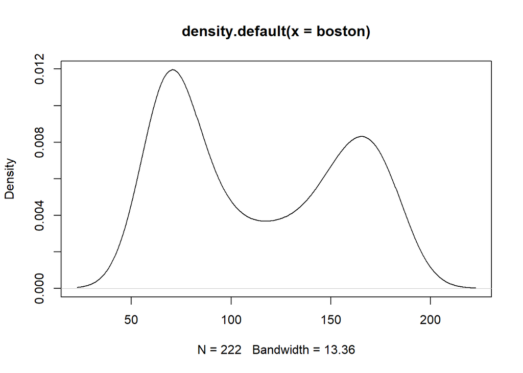

```r
plot(density(boston))
```

Let's examine the relationship between San Francisco Los Angeles more closely.

```r
CA<-mydata%>%
  select(contains("CA-"))

head(CA)
```

```
## # A tibble: 6 x 3
##   `CA-LosAngeles` `CA-SanDiego` `CA-SanFrancisco`
##             <dbl>         <dbl>             <dbl>
## 1            95.3          83.1              71.2
## 2            94.1          81.9              70.3
## 3            92.8          80.9              69.6
## 4            92.8          80.7              69.5
## 5            93.4          81.4              70.1
## 6            94.2          82.2              70.8
```

```r
colnames(CA)<-c("LA","SD","SF")

mymodel<-lm(SF~LA,data=CA)
summary(mymodel)
```

```
##
## Call:
## lm(formula = SF ~ LA, data = CA)
##
## Residuals:
##     Min      1Q  Median      3Q     Max
## -20.662  -7.739  -3.570   6.133  32.898
##
## Coefficients:
##             Estimate Std. Error t value Pr(>|t|)
## (Intercept) 14.95019    1.88959   7.912 1.23e-13 ***
## LA           0.76735    0.01251  61.358  < 2e-16 ***
## ---
## Signif. codes:  0 '***' 0.001 '**' 0.01 '*' 0.05 '.' 0.1 ' ' 1
##
## Residual standard error: 12.33 on 220 degrees of freedom
## Multiple R-squared:  0.9448, Adjusted R-squared:  0.9445
## F-statistic:  3765 on 1 and 220 DF,  p-value: < 2.2e-16
```

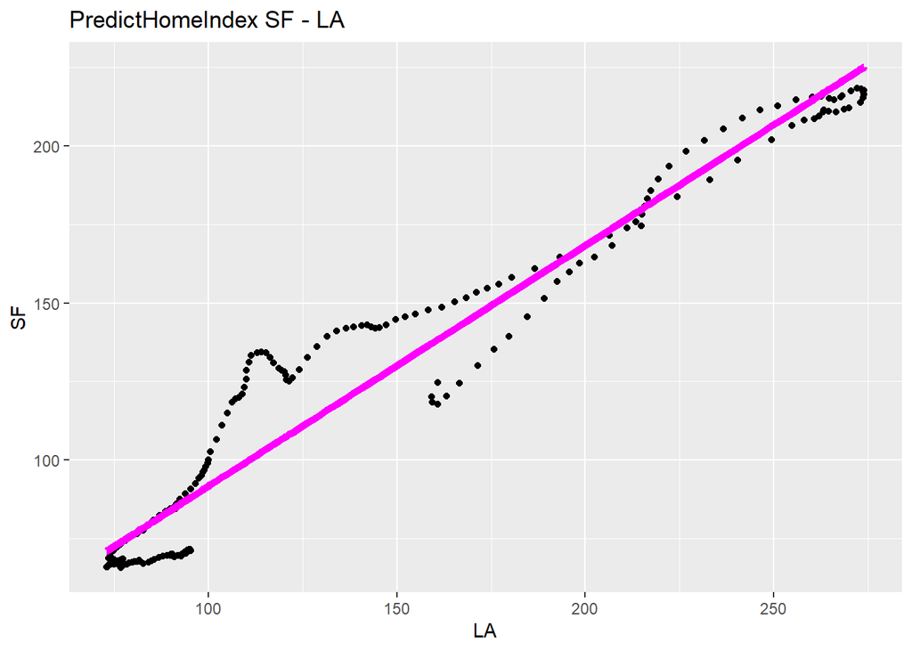

```r
CA$pred_sf = predict(mymodel,data=CA)

ggplot(data=CA, aes(x = LA)) +
geom_point(aes(y = SF)) +
geom_line(aes(y = pred_sf), color='Magenta', size=2) +
ggtitle("PredictHomeIndex SF - LA")
```

Final example, we want to see if the relationship between SF and LA change over time. Although not applicable, but this is the same concept as in pair trade in stock. If you have two stocks A and B and you believe their price relationship in the long-term should be stable. If you then a significant deviation of one stock's price, you could buy or sell, in anticipation of the relationship going back to normal in the near future.

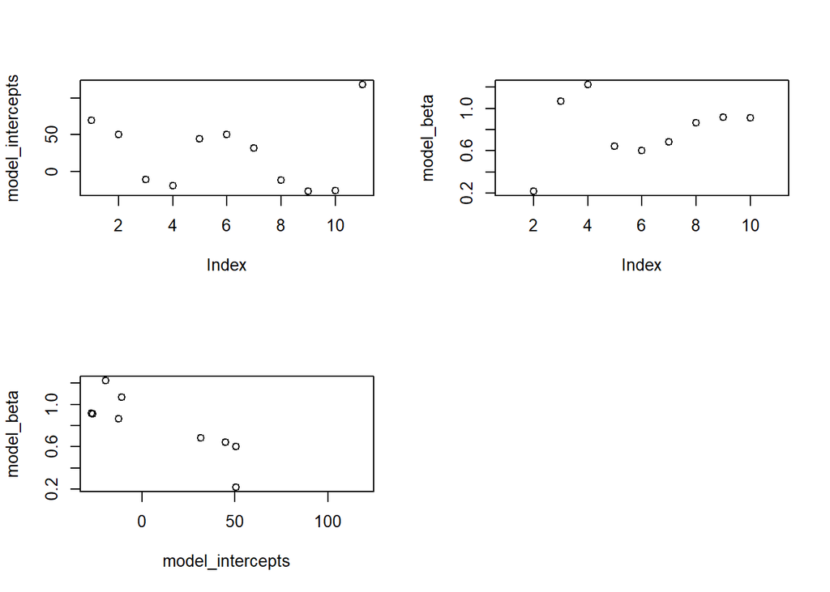

```r
mydata<-mydata%>%
  select(`CA-SanFrancisco`,`CA-LosAngeles`,date_field)%>%
  rename(SF=`CA-SanFrancisco`,LA=`CA-LosAngeles`)


model_intercepts<-numeric(11)
model_beta<-numeric(11)
for (i in 1:11){
  temp<-mydata[(i-1)*20+1:i*20,]
  mymodel<-lm(SF~LA,data=temp)
  model_intercepts[i]<-mymodel$coefficients[1]
  model_beta[i]<-mymodel$coefficients[2]
}


par(mfrow=c(2,2))
plot(model_intercepts)
plot(model_beta)
plot(model_intercepts,model_beta)
```